# 250310_motifbreak_R_NPC

Author

Chano Ranwala

## MotifbreakR Analysis : NPC MPRA

This document shows the preliminary motifbreakR analysis conducted on the significant SNPs found the in RenCell VM NPC MPRA.

#### Aim:

This quarto document identifies which of the NPC MPRA validated SNPs might have functional consequences by disrupting or creating transcription factor binding sites - potentially affecting gene regulation. This is a useful *in silico* follow up tool for interrogating the effectiveness of the MPRA chosen SNPs and prioritisation for further downstrema analysis.

```r
#load libraries
library(motifbreakR)
library(tidyverse)
library(BSgenome)
library("SNPlocs.Hsapiens.dbSNP155.GRCh38") # dbSNP155 in hg19
library("BSgenome.Hsapiens.UCSC.hg38")
library(MotifDb)
library(Cairo)
library(knitr)
library(kableExtra)
library(DT)
library(ggplot2)
library(dplyr)
```

We first load the SNP files

- Reads a file containing SNP identifiers (likely rsIDs like rs123456)
- Converts them to a character vector
- The `eval(parse())` is unusual here - it’s parsing and evaluating the strings (possibly to handle special formatting)

```r
#load SNP file list
all_SNPs_file <- system.file("SNPs", package = "motifbreakR")
all_SNPs_file <- "C:/Users/chano/Bioinformatics/250912_motifbreakR_NPC/SNPs"
all_snps <- read.table(all_SNPs_file, header = TRUE)
all_snps <- as.character(all_snps) #ensure eveyrthing is a character vector
all_snps <- eval(parse(text = all_snps)) #for the weird spacing issues for formatting
all_snps
```

```
 [1] "rs11065260" "rs11074027" "rs11260719" "rs1157456"  "rs1289345"
 [6] "rs13169806" "rs13237950" "rs1455407"  "rs1509635"  "rs2115365"
[11] "rs2238319"  "rs2238612"  "rs227578"   "rs2383435"  "rs2395952"
[16] "rs2395953"  "rs2585399"  "rs2727270"  "rs2727271"  "rs2747003"
[21] "rs2923776"  "rs34002332" "rs34974906" "rs3738290"  "rs3796812"
[26] "rs4078099"  "rs4298601"  "rs4355721"  "rs4385340"  "rs4487900"
[31] "rs4535686"  "rs4535686"  "rs4621754"  "rs550015"   "rs555001"
[36] "rs594216"   "rs60349318" "rs603862"   "rs60721428" "rs612392"
[41] "rs61777153" "rs61792505" "rs62016939" "rs62223052" "rs661983"
[46] "rs67026445" "rs6915285"  "rs6949073"  "rs6974780"  "rs7020300"
[51] "rs72827887" "rs72844686" "rs770189"   "rs7800161"  "rs79048848"
[56] "rs7968458"  "rs7968566"  "rs873748"   "rs979244"
```

## Getting SNP genomic coordinates

This provides a GRanges object for the SNPs we are interested in

```r
snps.mb <- snps.from.rsid(rsid = all_snps,
                          dbSNP = SNPlocs.Hsapiens.dbSNP155.GRCh38,
                          search.genome = BSgenome.Hsapiens.UCSC.hg38)
as.data.frame(snps.mb) %>%
  datatable(
    caption = "Interactive SNP Browser",
    filter = 'top',
    options = list(
      pageLength = 10,
      scrollX = TRUE,
      autoWidth = TRUE
    )
  )
```

|  | seqnames | start | end | width | strand | SNP_id | REF | ALT |
| --- | --- | --- | --- | --- | --- | --- | --- | --- |
| rs11065260 | chr12 | 120775052 | 120775052 | 1 | * | rs11065260 | A | G |
| rs11074027 | chr15 | 91954387 | 91954387 | 1 | * | rs11074027 | C | T |
| rs11260719 | chr1 | 16291416 | 16291416 | 1 | * | rs11260719 | C | T |
| rs1157456:A | chr3 | 70028570 | 70028570 | 1 | * | rs1157456 | G | A |
| rs1157456:C | chr3 | 70028570 | 70028570 | 1 | * | rs1157456 | G | C |
| rs1289345 | chr14 | 85701267 | 85701267 | 1 | * | rs1289345 | C | T |
| rs13169806:G | chr5 | 137194825 | 137194825 | 1 | * | rs13169806 | A | G |
| rs13169806:T | chr5 | 137194825 | 137194825 | 1 | * | rs13169806 | A | T |
| rs13237950:C | chr7 | 158707947 | 158707947 | 1 | * | rs13237950 | G | C |
| rs13237950:T | chr7 | 158707947 | 158707947 | 1 | * | rs13237950 | G | T |

[output cut: 69 more lines]

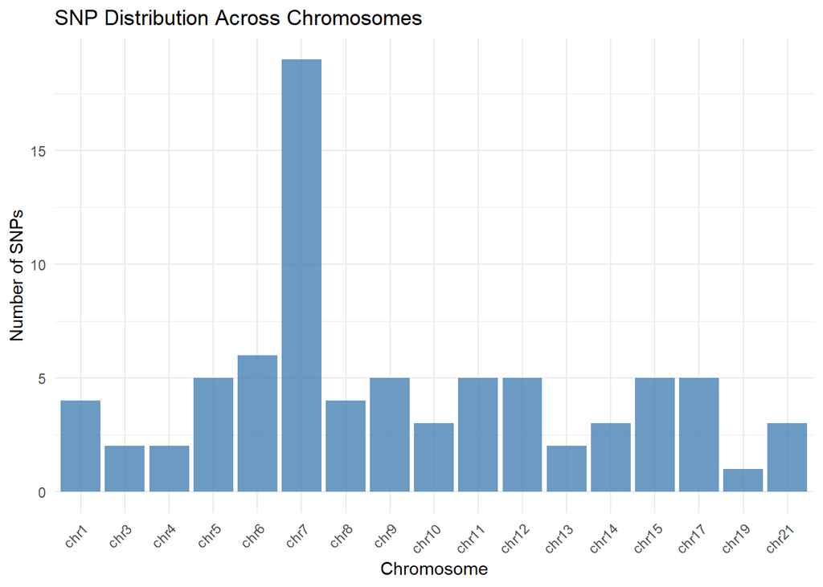

```r
#Also view as ggplot
as.data.frame(snps.mb) %>%
  ggplot(aes(x = seqnames)) +
  geom_bar(fill = "steelblue", alpha = 0.8) +
  theme_minimal() +
  labs(
    title = "SNP Distribution Across Chromosomes",
    x = "Chromosome",
    y = "Number of SNPs"
  ) +
  theme(axis.text.x = element_text(angle = 45, hjust = 1))
```

```r
#genomes <- available.genomes()
#length(genomes)

#table(mcols(MotifDb)$organism, mcols(MotifDb)$dataSource)
```

## Finding broken motifs

Load and find broken motifs. We use HOCOMOCO for this.

The motifDb database is a R package which is an annotated collection of Protein-DNA Binding Sequence Motifs. Link attached here https://bioconductor.org/packages/release/bioc/html/MotifDb.html. FOr people with no Chip-seq data this is a very valuable tool.

**HOCOMOCO** is a comprehensive collection of human transcription factor binding motifs (position weight matrices/PWMs). It represents a preferable binding spots for TFs. So if our SNPs are within those regions we would be able to see this. https://hocomoco11.autosome.org/

```r
#MotifDb
#table(mcols(MotifDb)$organism, mcols(MotifDb)$dataSource)
### Here we can see which organisms are availible under which sources
### in MotifDb
```

We have leveraged the `MotifList` introduced by [*MotifDb*](https://bioconductor.org/packages/3.22/MotifDb) to include an additional set of motifs that have been gathered to this package:

```r
data(motifbreakR_motif) #motiflist
#motifbreakR_motif
```

```r
data(hocomoco)
#hocomoco
```

## Final Analysis

The final analysis is as follows. Core parameters are defined below.

- **snpList**: Your SNPs with genomic coordinates
- **filterp = TRUE**: Only report results that pass the p-value threshold
- **pwmList = hocomoco**: Use HOCOMOCO motifs to test against
- **threshold = 1e-4**: Significance threshold (p < 0.0001)
- **method = “ic”**: Uses “information content” scoring to assess motif disruption
- **bkg**: Background nucleotide frequencies (assumes equal 25% for A, C, G, T)
- **BPPARAM**: Run serially (not in parallel) - better for windows because only SerialParam worked for me

```r
results_hocomoco <- motifbreakR(snpList = snps.mb, filterp = TRUE,
                       pwmList = hocomoco,
                       threshold = 1e-4, #can change this stringency
                       method = "ic",
                       bkg = c(A=0.25, C=0.25, G=0.25, T=0.25),
                       BPPARAM = BiocParallel::SerialParam()) #use this insteam to suit linunx like systemns

as.data.frame(results_hocomoco, row.names = NULL) %>%
  datatable(
    caption = "Transcription Factor Binding Sites Affected by SNPs",
    filter = 'top',
    options = list(
      pageLength = 15,
      scrollX = TRUE
    )
  )
```

|  | seqnames | start | end | width | strand | SNP_id | REF | ALT | varType | motifPos | geneSymbol | dataSource | providerName | providerId | seqMatch | pctRef | pctAlt | scoreRef | scoreAlt | Refpvalue | Altpvalue | altPos | alleleDiff | alleleEffectSize | effect |
| --- | --- | --- | --- | --- | --- | --- | --- | --- | --- | --- | --- | --- | --- | --- | --- | --- | --- | --- | --- | --- | --- | --- | --- | --- | --- |
| 1 | chr7 | 41374477 | 41374477 | 1 | - | rs7800161 | G | T | SNV | [1, 12] | NR2C2 | HOCOMOCO | NR2C2_f1 | NR2C2_HUMAN | cagacacaggagTgtcctttgcatt | 0.7438599561455478 | 0.8444216503902009 | 5.842982334740775 | 6.586085698091255 |  |  | 1 | 0.74310336335048 | 0.0960611053956087 | strong |
| 2 | chr6 | 65638272 | 65638272 | 1 | - | rs6915285 | G | A | SNV | [-8, 1] | CEBPA | HOCOMOCO | CEBPA_do | CEBPA_HUMAN | tgttgctcaAtaaagctcc | 0.8833535985156621 | 0.9763847305669674 | 5.824024541327411 | 6.419576945281675 |  |  | 1 | 0.5955524039542643 | 0.09063685003753864 | weak |
| 3 | chr7 | 158835318 | 158835318 | 1 | - | rs2383435 | A | G | SNV | [-9, 2] | INSM1 | HOCOMOCO | INSM1_f1 | INSM1_HUMAN | cctgcccccttAtcttgtatgca | 0.9039331178871527 | 0.8730708141437223 | 12.4543987635478 | 12.03456239117064 |  |  | 1 | -0.4198363723771585 | -0.03050859770056836 | weak |
| 4 | chr17 | 8151441 | 8151441 | 1 | - | rs2585399 | G | A | SNV | [-2, 12] | ZNF423 | HOCOMOCO | ZN423_f1 | ZN423_HUMAN | acactggtgggcgcAgccgggggggtcac | 0.6757641433743156 | 0.7530650712362377 | 14.81404860925211 | 16.479358939485 |  |  | 1 | 1.665310330232897 | 0.0763934286382391 | strong |
| 5 | chr8 | 129986635 | 129986635 | 1 | - | rs2395952 | T | C | SNV | [-3, 4] | MYCN | HOCOMOCO | MYCN_si | MYCN_HUMAN | ctcaccaCgtgatgc | 0.842810001100497 | 0.9922147429573908 | 8.317279624164877 | 9.78574476380846 |  |  | 1 | 1.468465139643582 | 0.1488973625067954 | strong |
| 6 | chr8 | 100986433 | 100986433 | 1 | + | rs2923776 | G | C | SNV | [-9, 5] | ZNF148 | HOCOMOCO | ZN148_si | ZN148_HUMAN | aaacagtgcaggggGagggtaggaagcac | 0.9226998750468103 | 0.837877788754624 | 10.36386322120137 | 9.436606300480369 |  |  | 1 | -0.9272569207209962 | -0.08272512110778142 | strong |
| 7 | chr7 | 158707947 | 158707947 | 1 | - | rs13237950 | G | T | SNV | [-3, 11] | IRF8 | HOCOMOCO | IRF8_si | IRF8_HUMAN | aaggcatcaagtaaTttctctttctggat | 0.8462647979886464 | 0.9547460522943724 | 8.594484514416486 | 9.659115654724003 |  |  | 1 | 1.064631140307517 | 0.1053752591081314 | strong |
| 8 | chr12 | 120775052 | 120775052 | 1 | + | rs11065260 | A | G | SNV | [-6, 6] | HLF | HOCOMOCO | HLF_si | HLF_HUMAN | tacgaggatgacGtaacctgtaagg | 0.8051939177173033 | 0.9446881705497253 | 7.840663369339871 | 9.166003126955385 |  |  | 1 | 1.325339757615514 | 0.1367524786683923 | strong |
| 9 | chr5 | 88792622 | 88792622 | 1 | - | rs770189 | G | T | SNV | [-4, 6] | TBP | HOCOMOCO | TBP_f1 | TBP_HUMAN | gcattctgttTtatatcttcc | 0.864686693014896 | 0.9735360618806288 | 4.774830511152444 | 5.356094821519735 |  |  | 1 | 0.5812643103672919 | 0.105734127380482 | weak |
| 10 | chr19 | 2149695 | 2149695 | 1 | - | rs2238612 | T | C | SNV | [-4, 5] | KLF4 | HOCOMOCO | KLF4_f2 | KLF4_HUMAN | tgaaaaccaCgccccagac | 0.8139153608291941 | 0.9721778904696267 | 8.117426356169492 | 9.670114035030767 |  |  | 1 | 1.552687678861275 | 0.1561577398409714 | strong |

[output cut: 162 more lines]

```r
neg_genes <- unique(mcols(results_hocomoco)$geneSymbol[mcols(results_hocomoco)$alleleDiff < 0])
pos_genes <- unique(mcols(results_hocomoco)$geneSymbol[mcols(results_hocomoco)$alleleDiff > 0])

both_directions <- intersect(neg_genes, pos_genes)
length(both_directions)
```

```
[1] 20
```

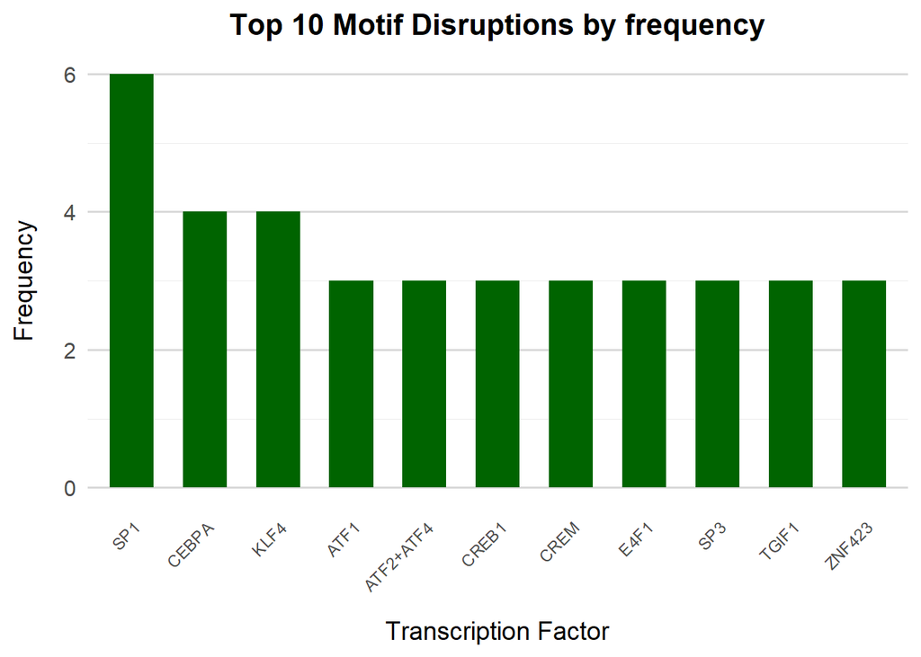

```r
  # Step 1: Extract transcription factor names
  all_tf_list <- mcols(results_hocomoco)$geneSymbol

  # Step 2: Count frequency of each TF
  all_tf_counts <- as.data.frame(table(all_tf_list)) %>%
    arrange(desc(Freq))

  # Step 3: Plot bar chart
  top_tf_counts <- all_tf_counts %>% slice_max(Freq, n = 10)

  ggplot(top_tf_counts, aes(x = reorder(all_tf_list, -Freq), y = Freq)) +
    geom_bar(stat = "identity", fill = "darkgreen", width = 0.6) +
    labs(
      x = "Transcription Factor",
      y = "Frequency",
      title = "Top 10 Motif Disruptions by frequency"
    ) +
    theme_minimal(base_size = 14) +
    theme(
      plot.title = element_text(face = "bold", hjust = 0.5, size = 16),
      axis.text.x = element_text(angle = 45, hjust = 1, size = 9, margin = margin(t = 10)),
      axis.text.y = element_text(size = 12),
      axis.title.x = element_text(margin = margin(t = 15)),
      axis.title.y = element_text(margin = margin(r = 15)),
    panel.grid.major.x = element_blank(),
    panel.grid.major.y = element_line(color = "gray85"),
    panel.background = element_rect(fill = "white", color = NA)
  )
```

```r
df <- as_tibble(results_hocomoco)

# Count how many TFs each SNP impacts
snp_tf_counts <- df %>%
  group_by(SNP_id) %>%                # SNP identifier column
  summarise(nTFs = n_distinct(geneSymbol)) %>%
  ungroup()

# Calculate the average
avg_tf_per_snp <- mean(snp_tf_counts$nTFs, na.rm = TRUE)
avg_tf_per_snp
```

```
[1] 3.717949
```

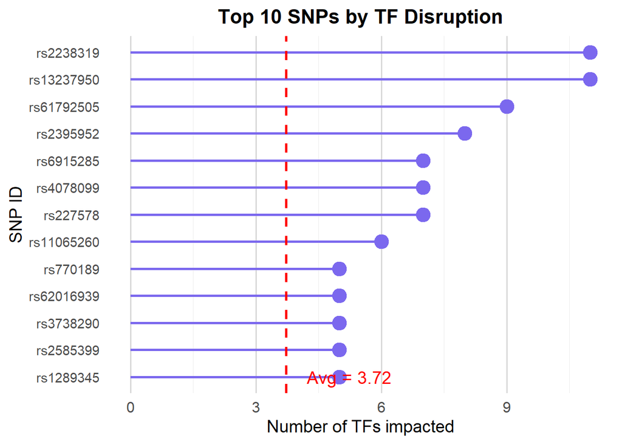

```r
# Calculate the average
avg_tf_per_snp <- mean(snp_tf_counts$nTFs, na.rm = TRUE)

# Lollipop plot

# Step 1: Get top 10 SNPs by number of TFs disrupted
top10_snps <- snp_tf_counts %>%
  arrange(desc(nTFs)) %>%
  slice_max(nTFs, n = 10)

# Step 2: Lollipop plot for top 10
ggplot(top10_snps, aes(x = nTFs, y = reorder(SNP_id, nTFs))) +
  geom_segment(aes(x = 0, xend = nTFs, yend = SNP_id), color = "#7B68EE", linewidth = 1) +
  geom_point(color = "#7B68EE", size = 5) +
  geom_vline(xintercept = avg_tf_per_snp, linetype = "dashed", color = "red", linewidth = 1) +
  annotate("text", x = avg_tf_per_snp + 0.5, y = 1,
           label = paste0("Avg = ", round(avg_tf_per_snp, 2)),
           color = "red", size = 5, hjust = 0) +
  labs(
    x = "Number of TFs impacted",
    y = "SNP ID",
    title = "Top 10 SNPs by TF Disruption"
  ) +
  theme_minimal(base_size = 14) +
  theme(
    plot.title = element_text(face = "bold", hjust = 0.5, size = 16),
    axis.text.y = element_text(size = 11),
    axis.text.x = element_text(size = 12),
    panel.grid.major.y = element_blank(),
    panel.grid.major.x = element_line(color = "gray85")
  )
```

[figure not shown]

```r
# Step 2: Count how many times each TF appears
all_tf_counts <- table(all_tf_list)

# Step 3: Count how many TFs appear each number of times
freq_of_freq <- as.data.frame(table(all_tf_counts))
colnames(freq_of_freq) <- c("Occurrences", "Num_TFs")

# Step 4: Plot
ggplot(freq_of_freq, aes(x = as.numeric(Occurrences), y = Num_TFs)) +
  geom_bar(stat = "identity", fill = "#4B9CD3", width = 0.7) +
  geom_text(aes(label = Num_TFs), vjust = -0.5, size = 3.5) +
  scale_x_continuous(breaks = scales::pretty_breaks(n = 10)) +
  labs(
    x = "Number of Occurrences",
    y = "Number of Transcription Factors",
    title = "Motif Disruption Frequency"
  ) +
  theme_minimal(base_size = 14) +
  theme(
    plot.title = element_text(face = "bold", hjust = 0.5),
    axis.text.x = element_text(angle = 0, vjust = 0.5),
    axis.text.y = element_text(color = "gray20"),
    panel.grid.major = element_line(color = "gray85"),
    panel.grid.minor = element_blank()
  )
```

#### Basic overview of what this does

- For each SNP, extracts the surrounding DNA sequence (reference and alternate alleles)
- Scans both sequences against all transcription factor motifs in HOCOMOCO
- Calculates binding scores for reference vs. alternate alleles
- Identifies which SNPs **break** (disrupt) or **create** transcription factor binding sites

```r
unique(mcols(results_hocomoco)$SNP_id) #Counts how many unique SNPs showed significant effects on transcription factor binding
```

```
 [1] "rs7800161"  "rs6915285"  "rs2383435"  "rs2585399"  "rs2395952"
 [6] "rs2923776"  "rs13237950" "rs11065260" "rs770189"   "rs2238612"
[11] "rs1289345"  "rs550015"   "rs61792505" "rs72844686" "rs4355721"
[16] "rs603862"   "rs227578"   "rs1157456"  "rs3738290"  "rs60721428"
[21] "rs1455407"  "rs62223052" "rs62016939" "rs2238319"  "rs873748"
[26] "rs67026445" "rs4298601"  "rs4078099"  "rs7968458"  "rs555001"
[31] "rs4535686"  "rs6974780"  "rs3796812"  "rs1509635"  "rs979244"
[36] "rs61777153" "rs11260719" "rs4385340"  "rs7968566"
```

```r
unique(results_hocomoco$SNP_id) #list of unique SNPs. No duplications
```

```
 [1] "rs7800161"  "rs6915285"  "rs2383435"  "rs2585399"  "rs2395952"
 [6] "rs2923776"  "rs13237950" "rs11065260" "rs770189"   "rs2238612"
[11] "rs1289345"  "rs550015"   "rs61792505" "rs72844686" "rs4355721"
[16] "rs603862"   "rs227578"   "rs1157456"  "rs3738290"  "rs60721428"
[21] "rs1455407"  "rs62223052" "rs62016939" "rs2238319"  "rs873748"
[26] "rs67026445" "rs4298601"  "rs4078099"  "rs7968458"  "rs555001"
[31] "rs4535686"  "rs6974780"  "rs3796812"  "rs1509635"  "rs979244"
[36] "rs61777153" "rs11260719" "rs4385340"  "rs7968566"
```

```r
unique(results_hocomoco$geneSymbol) #list of unique TFs. No duplications
```

```
  [1] "NR2C2"     "CEBPA"     "INSM1"     "ZNF423"    "MYCN"      "ZNF148"
  [7] "IRF8"      "HLF"       "TBP"       "KLF4"      "CEBPZ"     "ELK4"
 [13] "BACH1"     "FOSB"      "NFYB"      "NFYC"      "CREB1"     "REL"
 [19] "PPARD"     "RBPJ"      "RELB"      "SP4"       "RFX1"      "CEBPB"
 [25] "NFATC2"    "IRF2"      "SP1"       "JUN"       "FOSL1"     "SOX17"
 [31] "RFX2"      "FOSL2"     "NR1I3"     "MBD2"      "CTCF"      "USF1"
 [37] "GATA1"     "IRF9"      "FOXM1"     "FOXI1"     "CEBPD"     "CREM"
 [43] "SP3"       "ATF5"      "E4F1"      "RUNX1"     "GATA2"     "JUND"
 [49] "ATF2+ATF4" "RUNX3"     "BCL6"      "RREB1"     "RARB"      "USF2"
 [55] "IRF4"      "HOXC6"     "LHX2"      "TGIF1"     "MECOM"     "ATF6"
 [61] "MAX"       "ERG"       "MYC"       "THRB"      "JUNB"      "NR2C1"
 [67] "NKX2-2"    "NR3C1"     "BHLHE40"   "NR0B1"     "PRDM1"     "TP73"
 [73] "REST"      "TCF4"      "DDIT3"     "KLF3"      "FOXJ3"     "ARNTL"
 [79] "IRF7"      "ATF1"      "ESR2"      "RARG"      "BRCA1"     "NANOG"
 [85] "HES1"      "FOXC2"     "NR4A2"     "SMARCC1"   "HIVEP2"    "IRF3"
 [91] "STAT2"     "NR3C2"     "MAZ"       "RORA"      "CBFB"      "RXRB"
 [97] "ZBTB7B"    "BATF"      "RELA"      "CEBPE"     "TFEB"      "NR4A1"
[103] "PGR"       "POU4F2"    "POU2F1"    "NFKB2"     "NFATC3"    "NFYA"
[109] "CEBPG"     "SP2"       "NFATC1"    "EGR1"      "YY1"       "BPTF"
[115] "IRF1"      "BHLHE41"
```

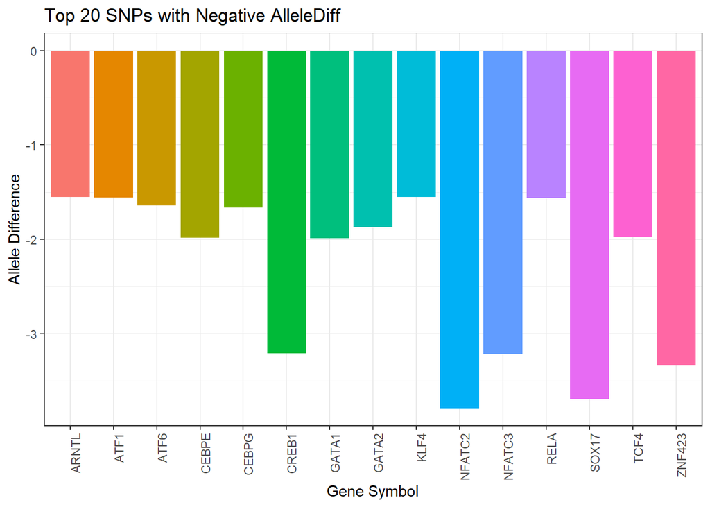

```r
# Step 1: Extract transcription factor names
alelle_dif <- data.frame(
  SNP_id     = results_hocomoco$SNP_id,
  geneSymbol = results_hocomoco$geneSymbol,
  alleleDiff = results_hocomoco$alleleDiff
)



# Filter for alleleDiff < 0 and take the top 20 by magnitude
top20_neg <- alelle_dif %>%
  filter(alleleDiff < 0) %>%
  arrange(alleleDiff) %>%   # ascending, so most negative first
  slice_head(n = 20)

# Plot by gene
ggplot(top20_neg, aes(x = geneSymbol, y = alleleDiff, fill = geneSymbol)) +
  geom_col() +
  labs(title = "Top 20 SNPs with Negative AlleleDiff",
       x = "Gene Symbol", y = "Allele Difference") +
  theme_bw() +
  theme(axis.text.x = element_text(angle = 90, hjust = 1),
        legend.position = "none")
```

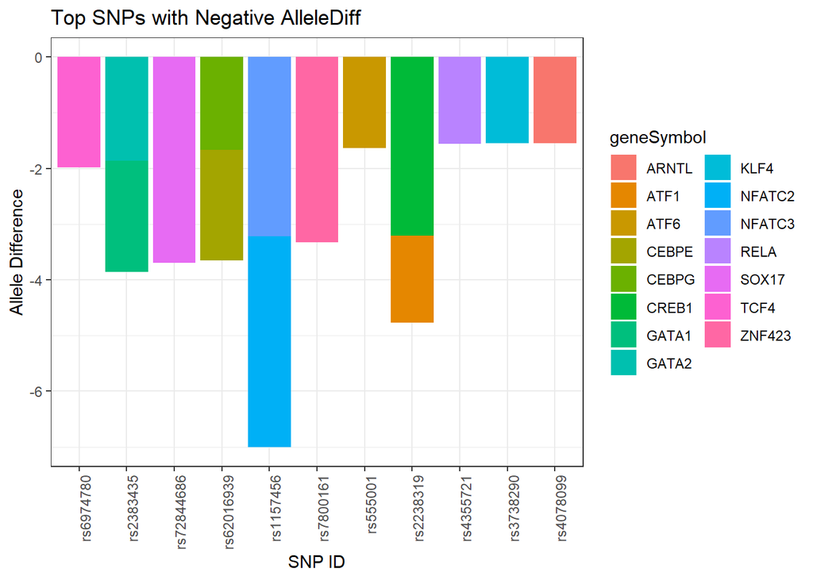

```r
top20_neg <- alelle_dif %>%
  filter(alleleDiff < 0) %>%
  arrange(alleleDiff) %>%
  slice_head(n = 20)

ggplot(top20_neg, aes(x = fct_reorder(SNP_id, alleleDiff, .desc = FALSE),
                      y = alleleDiff, fill = geneSymbol)) +
  geom_col() +
  labs(title = "Top SNPs with Negative AlleleDiff",
       x = "SNP ID", y = "Allele Difference") +
  theme_bw() +
  theme(axis.text.x = element_text(angle = 90, hjust = 1)) + guides(fill = guide_legend(ncol = 2))
```

[figure not shown]

```r
# Filter for alleleDiff < 0 and take the top 20 by magnitude
top20_pos <- alelle_dif %>%
  filter(alleleDiff > 0) %>%
  arrange(alleleDiff) %>%   # ascending, so most negative first
  slice_head(n = 20)

# Plot
ggplot(top20_pos, aes(x = geneSymbol, y = alleleDiff, fill = geneSymbol)) +
  geom_col() +
  labs(title = "Top 20 SNPs with Positive AlleleDiff",
       x = "Gene Symbol", y = "Allele Difference") +
  theme_bw() +
  theme(axis.text.x = element_text(angle = 90, hjust = 1),
        legend.position = "none")
```

[figure not shown]

```r
#by SNP
top20_pos <- alelle_dif %>%
  filter(alleleDiff > 0) %>%
  arrange(alleleDiff) %>%
  slice_head(n = 20)

ggplot(top20_pos, aes(x = SNP_id, y = alleleDiff, fill = geneSymbol)) +
  geom_col() +
  labs(title = "Top 20 SNPs with Positive AlleleDiff",
       x = "SNP ID", y = "Allele Difference") +
  theme_bw() +
  theme(axis.text.x = element_text(angle = 90, hjust = 1)) + guides(fill = guide_legend(ncol = 2))
```

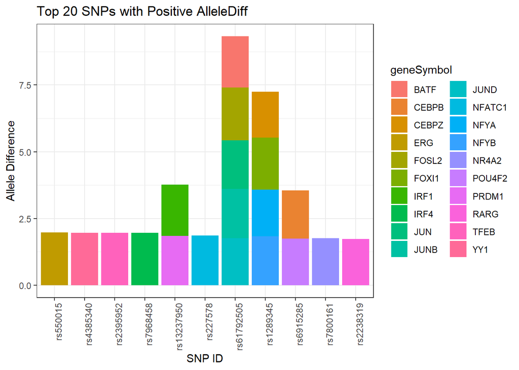

```r
library(forcats)

top20_pos <- alelle_dif %>%
  filter(alleleDiff > 0) %>%
  arrange(desc(alleleDiff)) %>%
  slice_head(n = 20)

ggplot(top20_pos, aes(x = fct_reorder(SNP_id, alleleDiff, .desc = TRUE),
                      y = alleleDiff, fill = geneSymbol)) +
  geom_col() +
  labs(title = "Top 20 SNPs with Positive AlleleDiff",
       x = "SNP ID", y = "Allele Difference") +
  theme_bw() +
  theme(axis.text.x = element_text(angle = 90, hjust = 1)) + guides(fill = guide_legend(ncol = 2))
```

To summarise,

```r
# Count unique SNPs
num_snps <- length(unique(mcols(results_hocomoco)$SNP_id))

# Count unique transcription factors
num_tfs <- length(unique(mcols(results_hocomoco)$geneSymbol))

# ANSI codes for bold and larger appearance (works in most R consoles)
bold_start <- "\033[1m"
bold_end <- "\033[0m"

# Print styled summary
cat(paste0("1. There are ", bold_start, num_snps, bold_end, " unique SNPs that disrupt transcription factor binding.\n"))
```

```
1. There are 39 unique SNPs that disrupt transcription factor binding.
```

```r
cat(paste0("2. There are ", bold_start, num_tfs, bold_end, " unique transcription factors with disrupted binding.\n"))
```

```
2. There are 116 unique transcription factors with disrupted binding.
```

```r
# Create frequency table
tf_freq_table <- as.data.frame(table(mcols(results_hocomoco)$geneSymbol)) %>%
  arrange(desc(Freq))

# Display frequency table using kable
kable(tf_freq_table, col.names = c("Transcription Factor", "Frequency"), caption = "Frequency of TF Motif Disruptions")
```

Frequency of TF Motif Disruptions

| Transcription Factor | Frequency |
| --- | --- |
| SP1 | 6 |
| CEBPA | 4 |
| KLF4 | 4 |
| ATF1 | 3 |
| ATF2+ATF4 | 3 |
| CREB1 | 3 |
| CREM | 3 |
| E4F1 | 3 |
| SP3 | 3 |
| TGIF1 | 3 |
| ZNF423 | 3 |
| BRCA1 | 2 |
| CEBPZ | 2 |
| GATA1 | 2 |
| HOXC6 | 2 |
| IRF4 | 2 |
| IRF9 | 2 |
| KLF3 | 2 |
| MAX | 2 |
| MAZ | 2 |
| MBD2 | 2 |
| MYC | 2 |
| MYCN | 2 |
| NFATC2 | 2 |
| NFATC3 | 2 |
| NFYC | 2 |
| NR1I3 | 2 |
| NR3C1 | 2 |
| PPARD | 2 |
| RARG | 2 |

[output cut: 86 more lines]

```r
# Step 1: Extract metadata safely
results_df <- as.data.frame(mcols(results_hocomoco))

# Step 2: Select relevant columns and remove duplicates
snp_tf_table <- results_df %>%
  select(SNP_id, geneSymbol) %>%
  distinct()

# Step 3: Group by SNP and collapse TFs into one line
snp_tf_summary <- snp_tf_table %>%
  group_by(SNP_id) %>%
  summarise(Disrupted_TFs = paste(unique(geneSymbol), collapse = ", ")) %>%
  arrange(SNP_id)

# Step 4: Display as a kable table
kable(snp_tf_summary, col.names = c("SNP (rsID)", "Disrupted Transcription Factors"), caption = "SNPs and Their Disrupted TFs")
```

SNPs and Their Disrupted TFs

| SNP (rsID) | Disrupted Transcription Factors |
| --- | --- |
| rs11065260 | HLF, CREB1, ATF2+ATF4, E4F1, CREM, ATF1 |
| rs11260719 | SP2, KLF3 |
| rs1157456 | NFATC2, CEBPA, NFATC3 |
| rs1289345 | CEBPZ, NFYB, FOXI1, NFYC, NFYA |
| rs13237950 | IRF8, IRF2, NR1I3, NKX2-2, PRDM1, IRF9, IRF7, IRF3, STAT2, IRF4, IRF1 |
| rs1455407 | IRF9, POU2F1 |
| rs1509635 | CEBPZ |
| rs2238319 | CREM, E4F1, ATF2+ATF4, RARB, THRB, NR2C1, CREB1, ATF1, ESR2, RARG, RXRB |
| rs2238612 | KLF4 |
| rs227578 | RBPJ, RELB, TP73, REL, NFKB2, RELA, NFATC1 |
| rs2383435 | INSM1, GATA2, GATA1, MECOM |
| rs2395952 | MYCN, USF1, MAX, BHLHE40, MYC, USF2, TFEB, BHLHE41 |
| rs2585399 | ZNF423, SP4, KLF4, MBD2, CTCF |
| rs2923776 | ZNF148, SP1, SP3, MAZ |
| rs3738290 | SP1, SP3, RREB1, KLF4, ZBTB7B |
| rs3796812 | FOXJ3 |
| rs4078099 | USF2, MYC, USF1, ARNTL, HES1, MAX, MYCN |
| rs4298601 | PPARD |
| rs4355721 | REL, RELB, HIVEP2, RELA |
| rs4385340 | YY1 |
| rs4535686 | NR0B1, REST, KLF3, EGR1 |
| rs550015 | ELK4, ERG |
| rs555001 | ATF6 |
| rs603862 | PPARD |
| rs60721428 | GATA1, ATF5, FOXC2 |
| rs61777153 | RORA |
| rs61792505 | BACH1, FOSB, JUN, FOSL1, FOSL2, JUND, JUNB, SMARCC1, BATF |
| rs62016939 | CEBPD, DDIT3, CEBPA, CEBPE, CEBPG |
| rs62223052 | FOXM1, TGIF1 |
| rs67026445 | BCL6 |
| rs6915285 | CEBPA, RFX1, CEBPB, RFX2, LHX2, NANOG, POU4F2 |
| rs6974780 | TCF4 |
| rs72844686 | NFYC, SOX17 |
| rs770189 | TBP, HOXC6, NR3C1, BRCA1, PGR |
| rs7800161 | NR2C2, ZNF423, NR4A2, NR4A1 |
| rs7968458 | IRF4, HOXC6 |
| rs7968566 | CEBPA |
| rs873748 | RUNX1, RUNX3, CBFB, BPTF |
| rs979244 | NR3C2 |

## Motif Disruption graphs

All motifbreakR generated graphs are as follows.

**A bit of helpful information ; Letter Height = Information Content**

The height of each letter is proportional to:

```
Letter height = Frequency × Information content
```

So:

- **Big letter** = common AND important = high conservation
- **Small letter** = rare OR unimportant = low conservation

  | Bits | Meaning | SNP Impact |
  | --- | --- | --- |
  | ~2.0 | Always this base | **STRONG** |
  | ~1.5 | Strong preference | **Moderate-Strong** |
  | ~1.0 | Moderate preference | **Moderate** |
  | ~0.5 | Weak preference | **Weak** |
  | ~0.0 | No preference | **Minimal** |

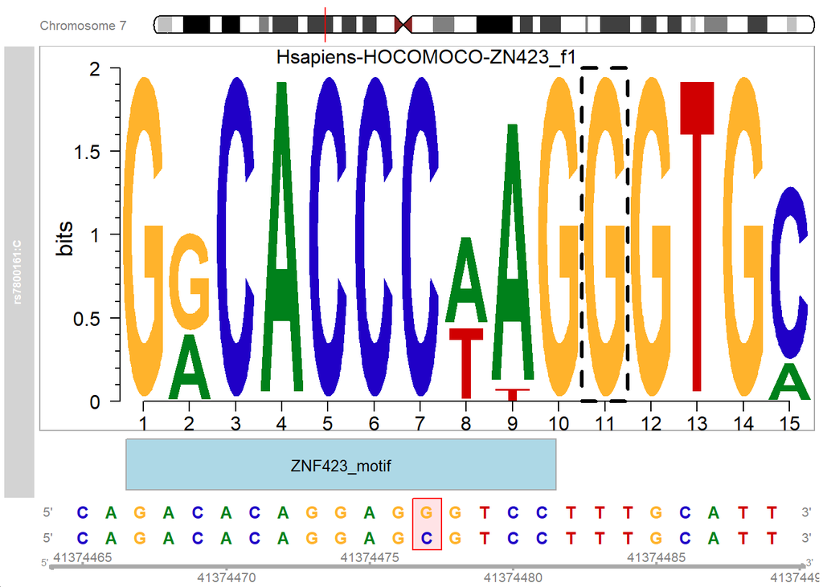

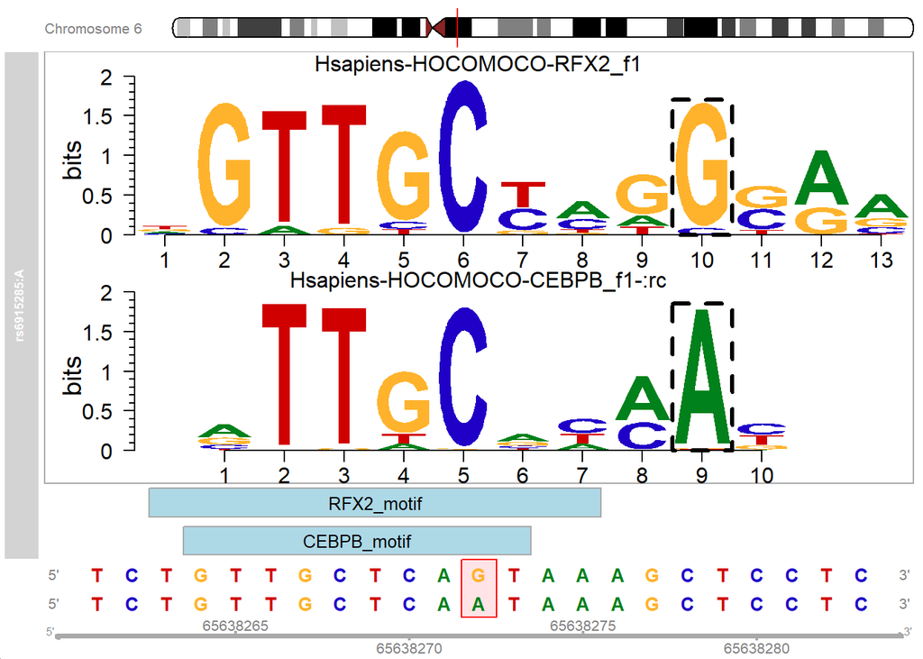

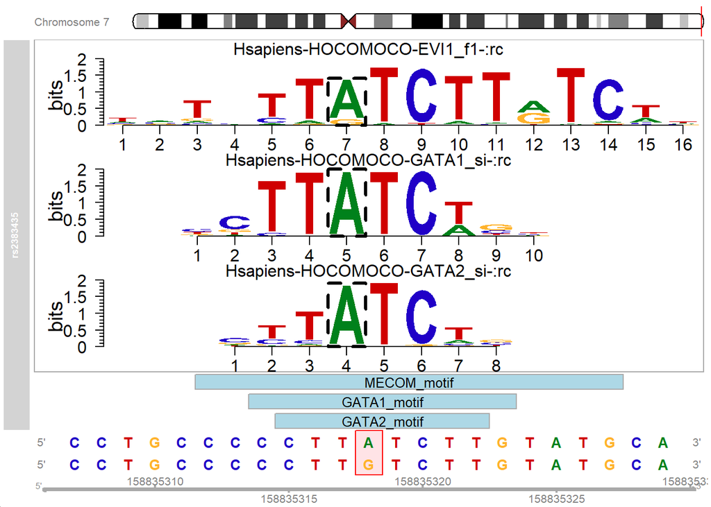

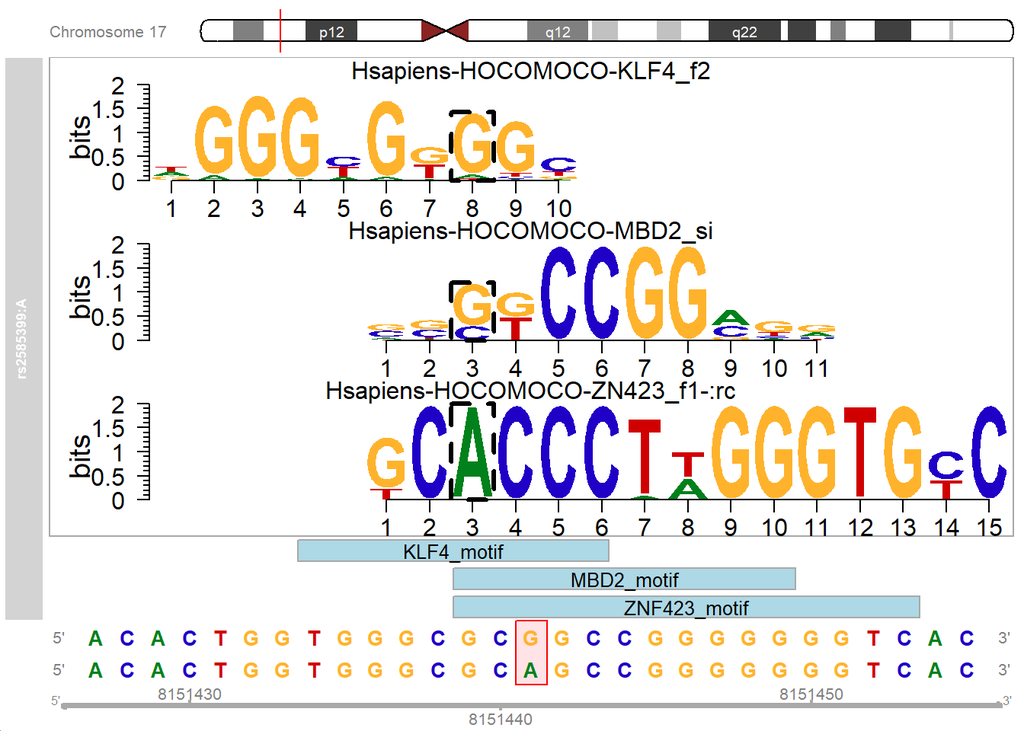

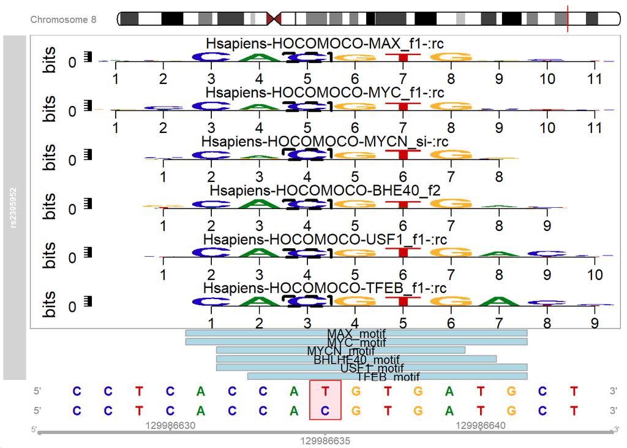

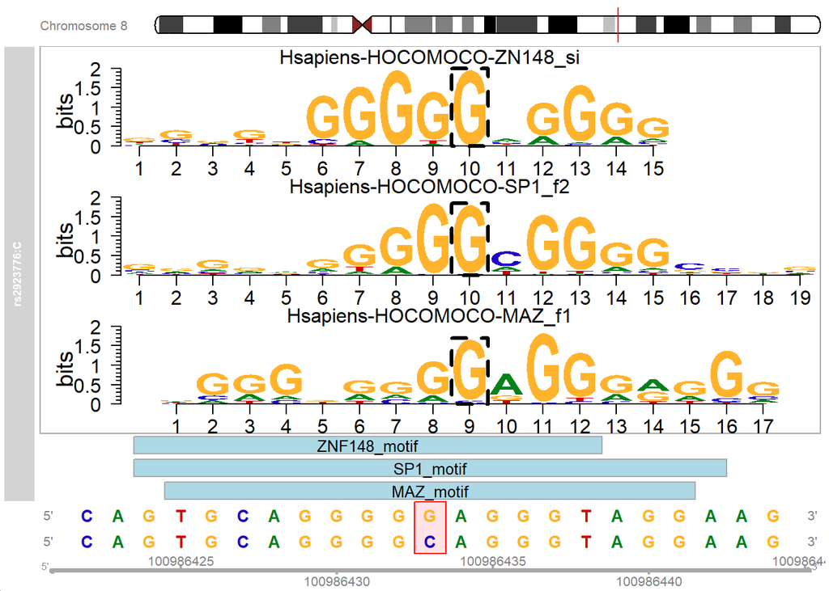

[figure not shown]

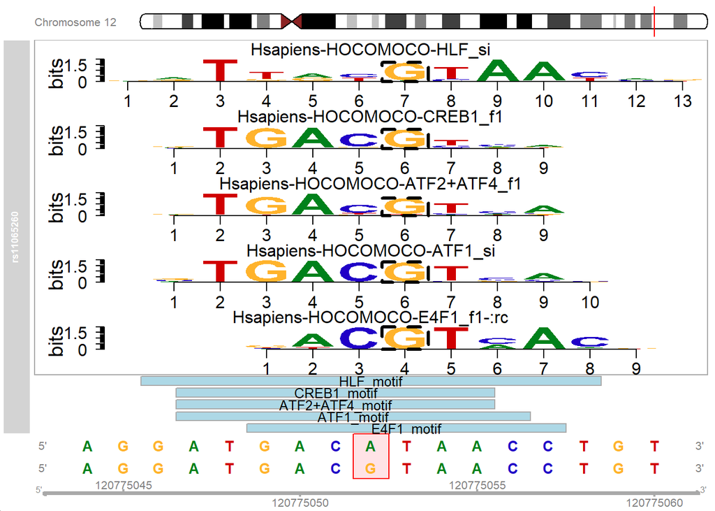

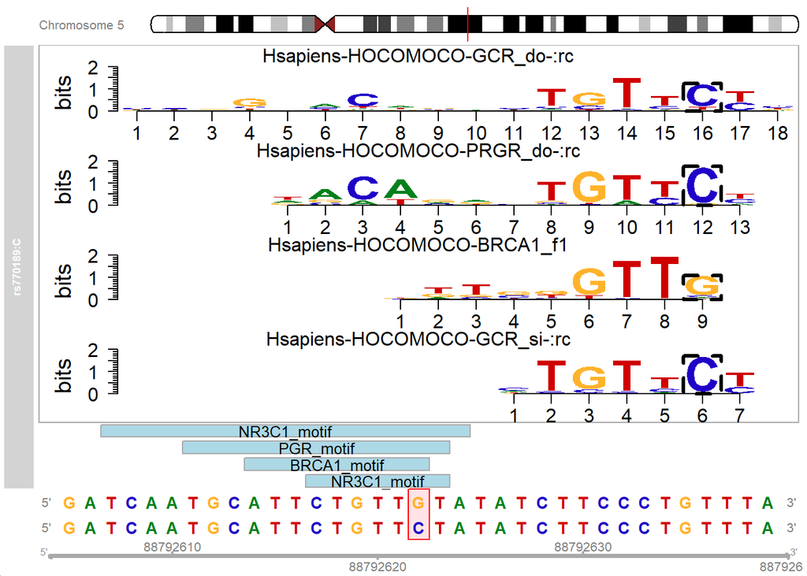

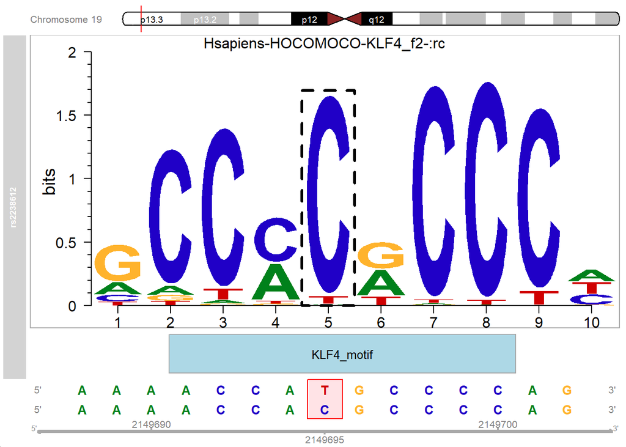

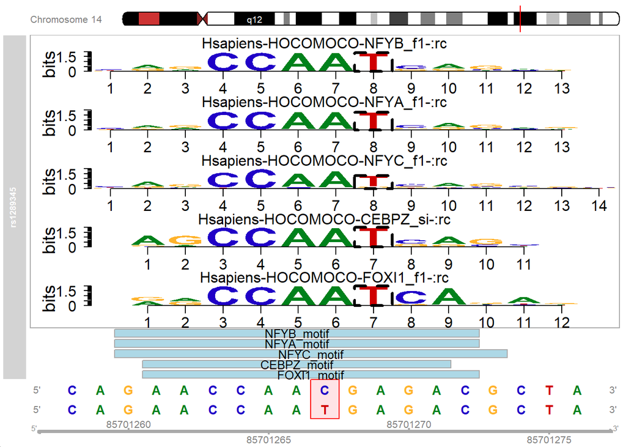

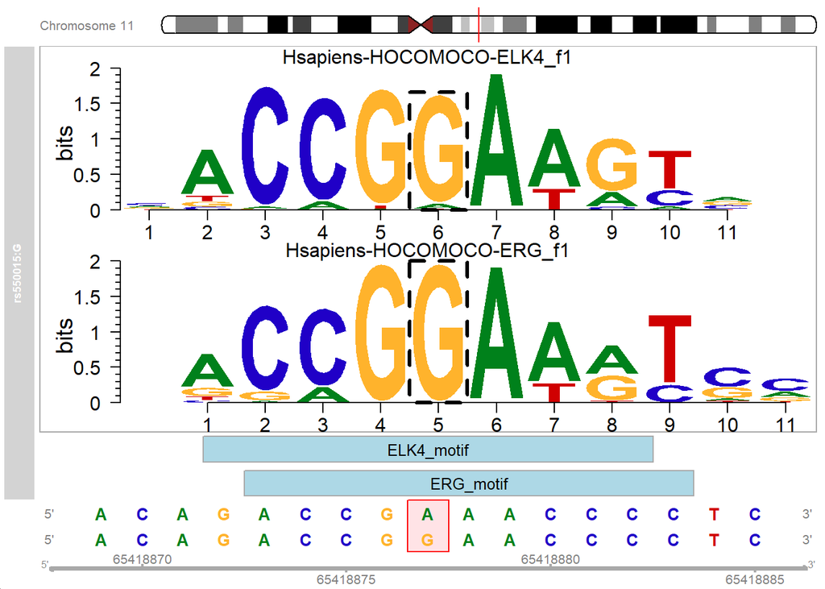

[23 more figures not shown]

```r
for (id in unique(mcols(results_hocomoco)$SNP_id)) {
  try({
    plotMB(results = results_hocomoco, rsid = id, effect = "strong")
    title(main = id)
  }, silent = TRUE)
}
```

## Further interrogation of transcription factors

To assess transcription factor enrichment for GO processes, I then did a pathway enrichment analysis using ShinyGO 0.85. I did this two ways.

1. Background as all human transcription factors
2. Background as all genes expressed in RenCell VM NPCs

### Method 1 : Background as all human transciption factors

[figure not shown]

GO biological processes

[figure not shown]

GO cellular component

[figure not shown]

GO molecular functions

[figure not shown]

KEGG pathway

### Method 2: Background as all genes expressed in RenVM NPCs

I used the RNA expression data from last year for this.

[figure not shown]

GO Biological processes

[figure not shown]

GO Cellular component

[figure not shown]

GO molecular function

[figure not shown]

GO KEGG